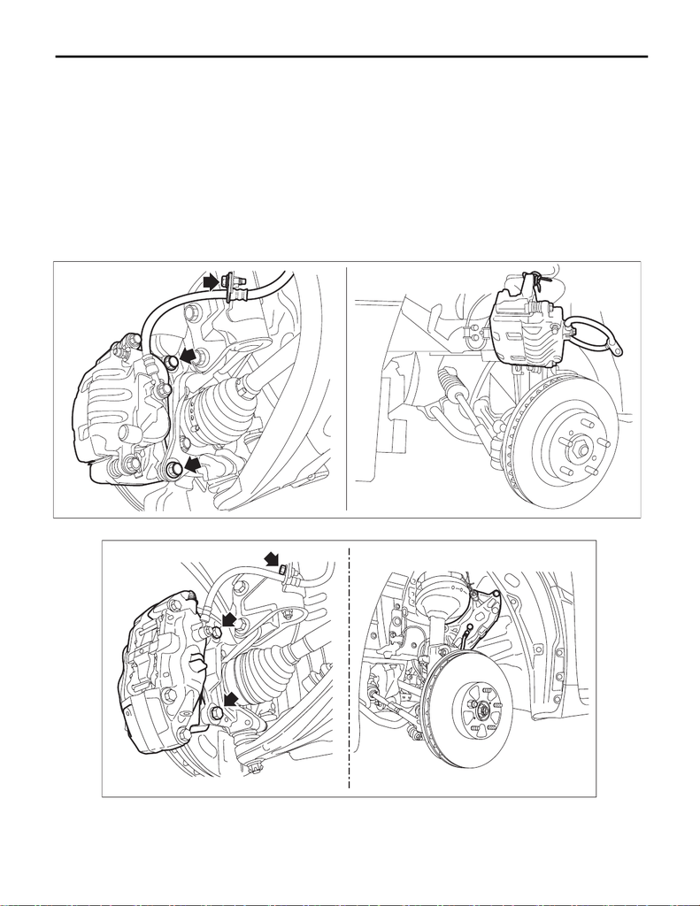

BR-22

Front Disc Rotor

BRAKE

3. Front Disc Rotor

A: REMOVAL

1) Lift up the vehicle, and then remove the front wheels.

2) Remove the disc brake assembly.

(1) Remove the brake hose bracket.

(2) Remove the mounting bolt, and remove the disc brake assembly.

(3) Prepare wiring harnesses etc. to be discarded, and suspend the disc brake assembly from the strut

assembly.

CAUTION:

Since the 17-inch (Brembo) caliper body is easily scratched and the paint may be stripped, protect it

from being contacted with other parts or tools.

• Except for STI model

•STI model

DS-00603

BR-01266

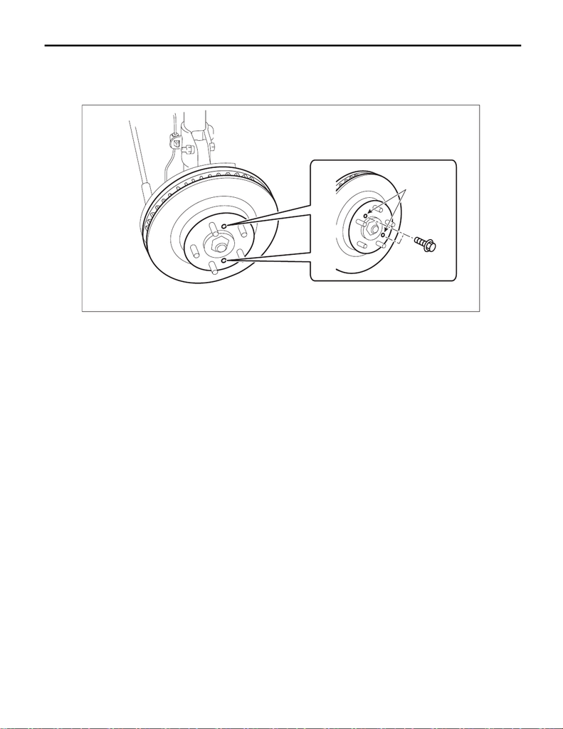

BR-23

Front Disc Rotor

BRAKE

3) Remove the disc rotor.

NOTE:

When the disc rotor is difficult to be removed, screw in 8 mm (0.31 in) bolt to the threaded part of the disc rotor

(A), and remove the disc rotor.

B: INSTALLATION

NOTE:

Before installation, remove mud and foreign matter from the disc brake assembly.

1) Check the front disc rotor. <Ref. to BR-23, INSPECTION, Front Disc Rotor.>

2) Install the disc rotor.

3) Install the disc brake assembly.

Tightening torque:

Mounting bolt (except for STI model): 80 N·m (8.2 kgf-m, 59.0 ft-lb)

Mounting bolt (STI model): 155 N·m (15.8 kgf-m, 114.3 ft-lb)

Brake hose bracket: 33 N·m (3.4 kgf-m, 24.3 ft-lb)

4) Install the front wheels.

Tightening torque:

120 N·m (12.2 kgf-m, 88.5 ft-lb)

C: INSPECTION

1. DISC ROTOR RUNOUT CHECK

1) Check the hub unit COMPL - front axle for free play and runout before the inspection of disc rotor runout

limit. <Ref. to DS-31, INSPECTION, Front Hub Unit Bearing.>

2) Tighten the wheel nuts to secure disc rotor.

BR-00922

(A)

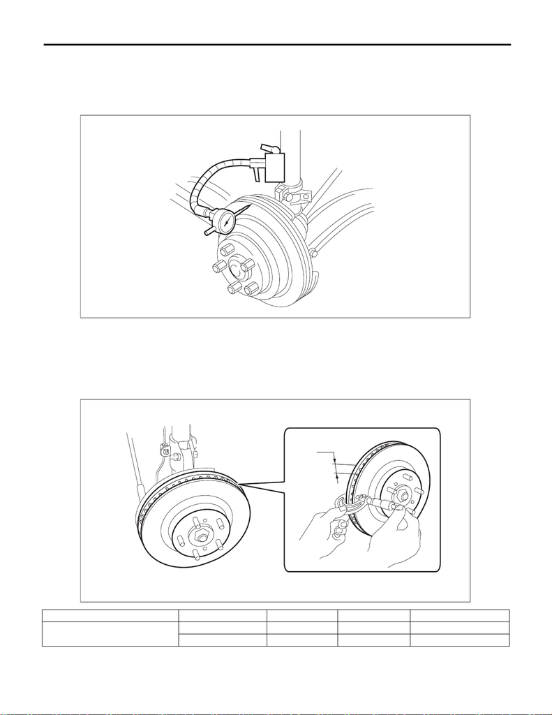

BR-24

Front Disc Rotor

BRAKE

3) Set a dial gauge 10 mm (0.39 in) inward from the disc rotor outer circumference, and check the disc rotor

runout while rotating the disc rotor.

Disc rotor runout limit

Except for STI model: 0.05 mm (0.0020 in)

STI model: 0.075 mm (0.0030 in)

4) If the disc rotor runout exceeds the limit, resurface the disc rotor.

5) After grinding, check the thickness of the disc rotor. <Ref. to BR-24, DISC ROTOR THICKNESS CHECK,

INSPECTION, Front Disc Rotor.>

2. DISC ROTOR THICKNESS CHECK

1) Set a micrometer 10 mm (0.39 in) inward from the disc rotor outer perimeter, and then measure the disc

rotor thickness (A).

2) If the wear limit is exceeded in the inspection, replace the disc rotor.

Size Standard Wear limit Disc rotor outer diameter

Disc rotor thickness (A)

Except for STI model 30 mm (1.18 in) 28 mm (1.10 in) 316 mm (12.44 in)

STI model 30 mm (1.18 in) 28 mm (1.10 in) 326 mm (12.83 in)

BR-00813

BR-00921

(A)